# Total Revenue Analysis using Multiple Linear Regression

Allan Omondi

2025-06-15

```
knitr::opts_chunk$set(echo = TRUE)
if (!"pacman" %in% installed.packages()[, "Package"]) {
  install.packages("pacman", dependencies = TRUE)
  library("pacman", character.only = TRUE)
}

pacman::p_load("here")

knitr::opts_knit$set(root.dir = here::here())
```

# 1 Load the Dataset

```
pacman::p_load("readr")

revenue_data <-
  read_csv("./data/siwaka_dishes_view_r_per_month_per_branch.csv", col_types = cols(
    Month = col_datetime(format = "%Y-%m"),
    BranchCounty = col_factor(levels = c("Kisumu", "Mombasa", "Nairobi", "Nakuru", "Nyeri", "Uasin Gishu")),
    TotalRevenue = col_double(),
    NumberOfOrders = col_integer(),
    AvgOrderValue = col_double()
    )
  )

head(revenue_data)
```

| Month | BranchCounty | TotalRevenue | NumberOfOrders | AvgOrderValue |
| --- | --- | --- | --- | --- |
| 2021-01-01 | Nairobi | 234.75 | 2 | 117.3750 |
| 2021-02-01 | Nairobi | 1178.66 | 5 | 235.7320 |
| 2021-03-01 | Kisumu | 269.18 | 1 | 269.1800 |
| 2021-03-01 | Nairobi | 2232.54 | 11 | 202.9582 |
| 2021-03-01 | Nakuru | 491.88 | 2 | 245.9400 |
| 2021-03-01 | Nyeri | 245.67 | 1 | 122.8350 |

# 2 Initial EDA

**View the Dimensions**

The number of observations and the number of variables.

```
dim(revenue_data)
```

```
[1] 293   5
```

**View the Data Types**

```
sapply(revenue_data, class)
```

```
$Month
[1] "POSIXct" "POSIXt"

$BranchCounty
[1] "factor"

$TotalRevenue
[1] "numeric"

$NumberOfOrders
[1] "integer"

$AvgOrderValue
[1] "numeric"
```

```
str(revenue_data)
```

```
spc_tbl_ [293 × 5] (S3: spec_tbl_df/tbl_df/tbl/data.frame)
 $ Month         : POSIXct[1:293], format: "2021-01-01" "2021-02-01" "2021-03-01" "2021-03-01" ...
 $ BranchCounty  : Factor w/ 6 levels "Kisumu","Mombasa",..: 3 3 1 3 4 5 6 1 3 2 ...
 $ TotalRevenue  : num [1:293] 235 1179 269 2233 492 ...
 $ NumberOfOrders: int [1:293] 2 5 1 11 2 1 1 1 4 1 ...
 $ AvgOrderValue : num [1:293] 117 236 269 203 246 ...
 - attr(*, "spec")=
  .. cols(
  ..   Month = col_datetime(format = "%Y-%m"),
  ..   BranchCounty = col_factor(levels = c("Kisumu", "Mombasa", "Nairobi", "Nakuru", "Nyeri", "Uasin Gishu"
  ..     ), ordered = FALSE, include_na = FALSE),
  ..   TotalRevenue = col_double(),
  ..   NumberOfOrders = col_integer(),
  ..   AvgOrderValue = col_double()
  .. )
 - attr(*, "problems")=<externalptr>
```

**Descriptive Statistics**

## 2.1 **Measures of Frequency**

This is applicable in cases where you have categorical variables, e.g., 60% of the observations are male and 40% are female (2 categories).

## 2.2 **Measures of Central Tendency**

The median and the mean of each numeric variable:

```
summary(revenue_data)
```

```
     Month                          BranchCounty  TotalRevenue       NumberOfOrders   AvgOrderValue
 Min.   :2021-01-01 00:00:00   Kisumu     :46    Min.   :    16.84   Min.   :  1.00   Min.   :  16.84
 1st Qu.:2022-05-01 00:00:00   Mombasa    :48    1st Qu.:  1039.57   1st Qu.:  4.00   1st Qu.: 245.94
 Median :2023-05-01 00:00:00   Nairobi    :53    Median :  2950.40   Median :  8.00   Median : 317.60
 Mean   :2023-04-28 17:46:29   Nakuru     :48    Mean   :  9982.73   Mean   : 27.93   Mean   : 349.46
 3rd Qu.:2024-05-01 00:00:00   Nyeri      :49    3rd Qu.:  6795.30   3rd Qu.: 17.00   3rd Qu.: 407.84
 Max.   :2025-05-01 00:00:00   Uasin Gishu:49    Max.   :191877.70   Max.   :424.00   Max.   :3176.72
```

## 2.3 **Measures of Distribution**

Measuring the variability in the dataset is important because the amount of variability determines **how well you can generalize** results from the sample to a new observation in the population.

Low variability is ideal because it means that you can better predict information about the population based on the sample data. High variability means that the values are less consistent, thus making it harder to make predictions.

### 2.3.1 **Variance**

```
sapply(revenue_data[,3:5], var)
```

```
  TotalRevenue NumberOfOrders  AvgOrderValue
  4.966248e+08   3.657074e+03   5.985350e+04
```

### 2.3.2 **Standard Deviation**

```
sapply(revenue_data[,3:5], sd)
```

```
  TotalRevenue NumberOfOrders  AvgOrderValue
   22285.08066       60.47374      244.64974
```

### 2.3.3 **Kurtosis**

The Kurtosis informs us of how often outliers occur in the results. There are different formulas for calculating kurtosis. Specifying “type = 2” allows us to use the 2nd formula which is the same kurtosis formula used in other statistical software like SPSS and SAS.

In “type = 2” (used in SPSS and SAS):

1. Kurtosis < 3 implies a low number of outliers
2. Kurtosis = 3 implies a medium number of outliers
3. Kurtosis > 3 implies a high number of outliers

```
pacman::p_load("e1071")
sapply(revenue_data[,3:5],  kurtosis, type = 2)
```

```
  TotalRevenue NumberOfOrders  AvgOrderValue
      23.65609       16.18100       61.89566
```

### 2.3.4 **Skewness**

The skewness is used to identify the asymmetry of the distribution of results. Similar to kurtosis, there are several ways of computing the skewness.

Using “type = 2” (common in other statistical software like SPSS and SAS) can be interpreted as:

1. Skewness between -0.4 and 0.4 (inclusive) implies that there is no skew in the distribution of results; the distribution of results is symmetrical; it is a normal distribution; a Gaussian distribution.
2. Skewness above 0.4 implies a positive skew; a right-skewed distribution.
3. Skewness below -0.4 implies a negative skew; a left-skewed distribution.

```
sapply(revenue_data[,3:5], skewness, type = 2)
```

```
  TotalRevenue NumberOfOrders  AvgOrderValue
      4.389305       3.818523       5.974981
```

## 2.4 **Measures of Relationship**

### 2.4.1 **Covariance**

Covariance is a statistical measure that indicates the direction of the linear relationship between two variables. It assesses whether increases in one variable correspond to increases or decreases in another.

- **Positive Covariance:** When one variable increases, the other tends to increase as well.
- **Negative Covariance:** When one variable increases, the other tends to decrease.
- **Zero Covariance:** No linear relationship exists between the variables.

While covariance indicates the direction of a relationship, it does not convey the strength or consistency of the relationship. The correlation coefficient is used to indicate the strength of the relationship.

```
cov(revenue_data[,3:5], method = "spearman")
```

```
               TotalRevenue NumberOfOrders AvgOrderValue
TotalRevenue       7178.500       6741.812      3162.942
NumberOfOrders     6741.812       7155.392      1143.348
AvgOrderValue      3162.942       1143.348      7178.500
```

### 2.4.2 **Correlation**

A strong correlation between variables enables us to better predict the value of the dependent variable using the value of the independent variable. However, a weak correlation between two variables does not help us to predict the value of the dependent variable from the value of the independent variable. This is useful only if there is a linear association between the variables.

We can measure the statistical significance of the correlation using Spearman’s rank correlation *rho*. This shows us if the variables are significantly monotonically related. A monotonic relationship between two variables implies that as one variable increases, the other variable either consistently increases or consistently decreases. The key characteristic is the preservation of the direction of change, though the rate of change may vary.

To view the correlation of all variables at the same time

```
cor(revenue_data[,3:5], method = "spearman")
```

```
               TotalRevenue NumberOfOrders AvgOrderValue
TotalRevenue      1.0000000      0.9406825     0.4406132
NumberOfOrders    0.9406825      1.0000000     0.1595309
AvgOrderValue     0.4406132      0.1595309     1.0000000
```

## 2.5 **Basic Visualizations**

### 2.5.1 **Histogram**

```
par(mfrow = c(1, 2))
for (i in 1:5) {
  if (is.numeric(revenue_data[[i]])) {
    hist(revenue_data[[i]],
         main = names(revenue_data)[i],
         xlab = names(revenue_data)[i])
  } else {
    message(paste("Column", names(revenue_data)[i], "is not numeric and will be skipped."))
  }
}
```

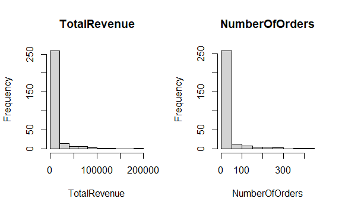

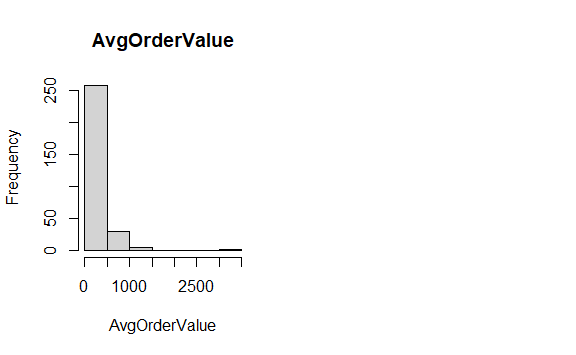

### 2.5.2 **Box and Whisker Plot**

```
# `boxplot()` This is the function used to plot the box and whisker plot visualization
par(mfrow = c(1, 2))
for (i in 1:5) {
  if (is.numeric(revenue_data[[i]])) {
    boxplot(revenue_data[[i]], main = names(revenue_data)[i])
  } else {
    message(paste("Column", names(revenue_data)[i], "is not numeric and will be skipped."))
  }
}
```

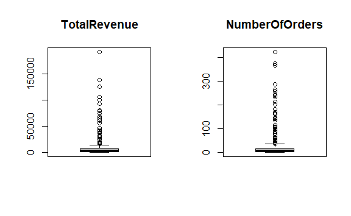

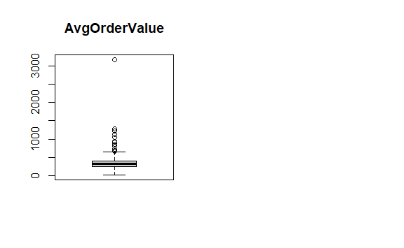

### 2.5.3 **Missing Data Plot**

```
pacman::p_load("Amelia")

missmap(revenue_data, col = c("red", "grey"), legend = TRUE)
```

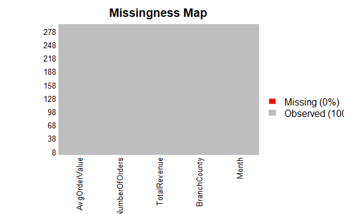

### 2.5.4 **Correlation Plot**

```
pacman::p_load("ggcorrplot")

ggcorrplot(cor(revenue_data[,3:5]))
```

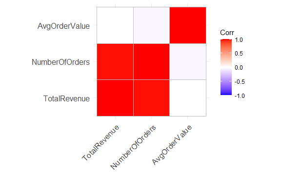

### 2.5.5 **Scatter Plot**

```
pacman::p_load("corrplot")

pairs(TotalRevenue ~ ., data = revenue_data, col = revenue_data$BranchCounty)
```

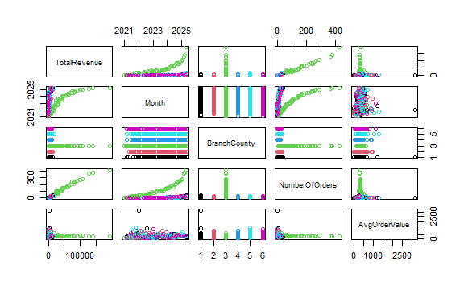

```
pacman::p_load("ggplot2")
ggplot(revenue_data,
       aes(x = Month, y = TotalRevenue)) +
  geom_point() +
  geom_smooth(method = lm) +
  labs(
    title = "Relationship between Total Revenue and Month",
    x = "Month",
    y = "Total Revenue"
  )
```

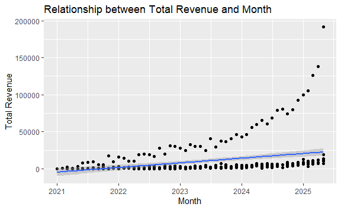

```
ggplot(revenue_data,
       aes(x = Month, y = TotalRevenue, color = BranchCounty)) +
  geom_point() +
  geom_smooth(method = lm) +
  labs(
    title = "Relationship between Total Revenue and Month per County",
    x = "Month",
    y = "Total Revenue",
    color = "County"
  ) +
  theme_minimal()
```

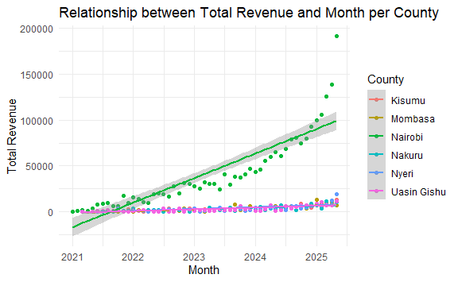

# 3 Statistical Test

We then apply a simultaneous multiple linear regression as a statistical test for regression. The term “simultaneous” refers to how the predictor variables are entered and considered in the statistical test. It means that all the predictor variables included in the model are entered and evaluated at the same time.

```
mlr_test <- lm(TotalRevenue ~ Month + NumberOfOrders + AvgOrderValue, data = revenue_data)
```

View the summary of the model.

```
summary(mlr_test)
```

```
Call:
lm(formula = TotalRevenue ~ Month + NumberOfOrders + AvgOrderValue,
    data = revenue_data)

Residuals:
   Min     1Q Median     3Q    Max
-14466   -372    245    620  37410

Coefficients:
                 Estimate Std. Error t value Pr(>|t|)
(Intercept)    -6.441e+03  8.527e+03  -0.755    0.451
Month           3.055e-06  5.082e-06   0.601    0.548
NumberOfOrders  3.646e+02  3.188e+00 114.359  < 2e-16 ***
AvgOrderValue   3.152e+00  7.419e-01   4.249  2.9e-05 ***
---
Signif. codes:  0 ‘***’ 0.001 ‘**’ 0.01 ‘*’ 0.05 ‘.’ 0.1 ‘ ’ 1

Residual standard error: 3099 on 289 degrees of freedom
Multiple R-squared:  0.9809,    Adjusted R-squared:  0.9807
F-statistic:  4936 on 3 and 289 DF,  p-value: < 2.2e-16
```

To obtain a 95% confidence interval:

```
confint(mlr_test, level = 0.95)
```

```
                       2.5 %       97.5 %
(Intercept)    -2.322263e+04 1.034131e+04
Month          -6.946674e-06 1.305656e-05
NumberOfOrders  3.582761e+02 3.708245e+02
AvgOrderValue   1.691973e+00 4.612218e+00
```

# 4 Diagnostic EDA

Diagnostic EDA is performed to validate that the regression assumptions are true with respect to the statistical test. Validating the regression assumption in turn ensures that the statistical tests applied are appropriate for the data and helps to prevent incorrect conclusions.

## 4.1 **Test of Linearity**

The test of linearity is used to assess whether the relationship between the dependent variables and the independent variables is linear. This is necessary given that linearity is one of the key assumptions of statistical tests of regression and verifying it is crucial for ensuring the validity of the model’s estimates and predictions.

A plot of the residuals versus the fitted values enables us to test for linearity. For the model to pass the test of linearity, there should be no pattern in the distribution of residuals and the residuals should be randomly placed around the 0.0 residual line, i.e., the residuals should randomly vary around the mean of the value of the response variable.

```
plot(mlr_test, which = 1)
```

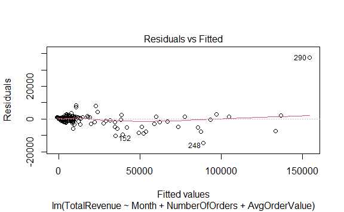

## 4.2 **Test of Independence of Errors (Autocorrelation)**

This test is necessary to confirm that each observation is independent of the other. It helps to identify **autocorrelation** that is introduced when the data is collected over a close period of time or when one observation is related to another observation. Autocorrelation leads to underestimated standard errors and inflated t-statistics. It can also make findings appear more significant than they actually are.

The “**Durbin-Watson Test**” can be used as a test of independence of errors (test of autocorrelation). A Durbin-Watson statistic close to 2 suggests no autocorrelation, while values approaching 0 or 4 indicate positive or negative autocorrelation, respectively.

- The null hypothesis, H<sub>0</sub>, is that there is no autocorrelation
- The alternative hypothesis, H<sub>a</sub>, is that there is autocorrelation

If the p-value of the Durbin-Watson statistic is greater than 0.05 then there is no evidence to reject the null hypothesis that “there is no autocorrelation”. The results below show a p-value of `0.5061`, therefore, the test of independence of errors around the regression line passes.

```
pacman::p_load("lmtest")
dwtest(mlr_test)
```

```
    Durbin-Watson test

data:  mlr_test
DW = 2.0071, p-value = 0.5061
alternative hypothesis: true autocorrelation is greater than 0
```

## 4.3 **Test of Normality**

The test of normality assesses whether the residuals are normally distributed, i.e., most residuals (errors) are close to zero and large errors are rare. A Q-Q plot can be used to conduct the test of normality.

A Quantile-Quantile (Q-Q) plot is a scatterplot of the quantiles of the residuals against the quantiles of a normal distribution. Quantiles are statistical values that divide a dataset or probability distribution into equal-sized intervals. They help in understanding how data is distributed by marking specific points that separate the data into groups of equal size. Examples of quantiles include: quartiles (4 equal parts), percentiles (100 equal parts), deciles (10 equal parts), etc.

If the points in the Q-Q plot fall along a straight line, then the normality assumption is satisfied. If the points in the Q-Q plot do not fall along a straight line, then the normality assumption is not satisfied.

```
plot(mlr_test, which = 2)
```

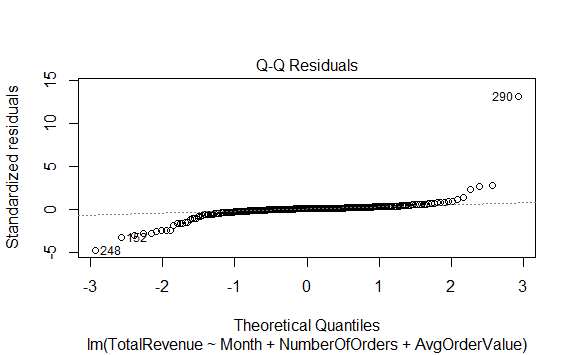

## 4.4 **Test of Homoscedasticity**

Homoscedasticity requires that the spread of residuals should be constant across all levels of the independent variable. A scale-location plot (a.k.a. spread-location plot) can be used to conduct a test of homoscedasticity.

The x-axis shows the fitted (predicted) values from the model and the y-axis shows the square root of the standardized residuals. The red line is added to help visualize any patterns.

In a model with homoscedastic errors (equal variance across all predicted values):

- Points should be randomly scattered around a horizontal line
- The smooth line should be approximately horizontal
- The vertical spread of points should be roughly equal across all fitted values
- No obvious patterns, funnels, or trends should be visible

Points forming a cone shape that widens from left to right suggests heteroscedasticity with increasing variance for larger fitted values.

```
plot(mlr_test, which = 3)
```

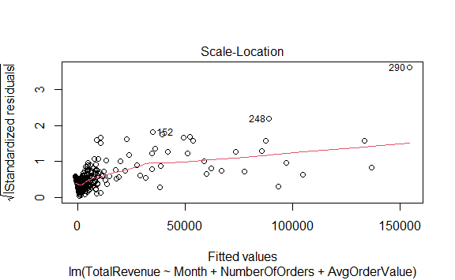

**Breusch-Pagan Test**

The Breusch-Pagan Test can also be used in addition to the visual inspection of a Scale-Location plot

**Interpretation:** If the p-value is less than 0.05, there is statistically significant evidence of heteroscedasticity in the residuals.

```
pacman::p_load("lmtest")
lmtest::bptest(mlr_test)
```

```
    studentized Breusch-Pagan test

data:  mlr_test
BP = 65.517, df = 3, p-value = 3.888e-14
```

## 4.5 **Quantitative Validation of Assumptions**

The graphical representations of the various tests of assumptions should be accompanied by quantitative values. The `gvlma` package (Global Validation of Linear Models Assumptions) is useful for this purpose.

```
pacman::p_load("gvlma")
gvlma_results <- gvlma(mlr_test)
summary(gvlma_results)
```

|  | Value | p-value | Decision |
| --- | --- | --- | --- |
| Global Stat | 70925.19150 | 0 | Assumptions NOT satisfied! |
| Skewness | 1384.47552 | 0 | Assumptions NOT satisfied! |
| Kurtosis | 69268.35721 | 0 | Assumptions NOT satisfied! |
| Link Function | 98.04806 | 0 | Assumptions NOT satisfied! |
| Heteroscedasticity | 174.31070 | 0 | Assumptions NOT satisfied! |

```
Call:
lm(formula = TotalRevenue ~ Month + NumberOfOrders + AvgOrderValue,
    data = revenue_data)

Residuals:
   Min     1Q Median     3Q    Max
-14466   -372    245    620  37410

Coefficients:
                 Estimate Std. Error t value Pr(>|t|)
(Intercept)    -6.441e+03  8.527e+03  -0.755    0.451
Month           3.055e-06  5.082e-06   0.601    0.548
NumberOfOrders  3.646e+02  3.188e+00 114.359  < 2e-16 ***
AvgOrderValue   3.152e+00  7.419e-01   4.249  2.9e-05 ***
---
Signif. codes:  0 ‘***’ 0.001 ‘**’ 0.01 ‘*’ 0.05 ‘.’ 0.1 ‘ ’ 1

Residual standard error: 3099 on 289 degrees of freedom
Multiple R-squared:  0.9809,    Adjusted R-squared:  0.9807
F-statistic:  4936 on 3 and 289 DF,  p-value: < 2.2e-16


ASSESSMENT OF THE LINEAR MODEL ASSUMPTIONS
USING THE GLOBAL TEST ON 4 DEGREES-OF-FREEDOM:
Level of Significance =  0.05

Call:
 gvlma(x = mlr_test)
```

## 4.6 Test of Multicollinearity

Multicollinearity arises when two or more independent variables (predictors) are highly intercorrelated. The **Variance Inflation Factor (VIF)** quantifies how much the variance of a coefficient estimate is “inflated” due to multicollinearity. A VIF of 1 indicates no collinearity; values above 5 suggest problematic levels of collinearity. High VIF values (VIF > 5) suggest that the coefficient estimates are less reliable due to the correlations between predictors.

```
pacman::p_load("car")
vif(mlr_test)
```

```
         Month NumberOfOrders  AvgOrderValue
      1.128298       1.129655       1.001305
```

# 5 Interpretation of the Results

## 5.1 Academic Statement

A simultaneous multiple linear regression analysis was conducted on data from 293 observations (N=293) to examine whether the month, the number of orders, and the average order value collectively predict total revenue. The results indicated that the number of orders ($\beta$ = 364.60, 95% CI [358.28, 370.82], SE = 3.19, *t*(289) = 114.36, *p* = < .001) and the average order value ($\beta$ = 3.15, 95% CI [1.69, 4.61], SE = 0.74, *t*(289) = 4.25, *p* = < .001) individually significantly predicted the total revenue (all *p* < 0.05). The model explained 98.07% of the variance in total revenue (Multiple R<sup>2</sup> = .98, Adjusted R<sup>2</sup> = .98, *F*(3, 289) = 4,936, *p* < .001). The intercept was -6,441, 95% CI [-23,222.63, 10,341.31], SE = 8,527, *t*(289) = -0.76, *p* = 0.45. The residual standard error was 3,099, indicating a robust model. The full results are presented in the table below.

Regression Coefficients Predicting Total Revenue from Month, Number of Orders, and Average Value

| Predictor | $\beta$ | 95% CI | SE | *t*(289) | *p* |
| --- | --- | --- | --- | --- | --- |
| (Intercept) | -6,441 | [-23,222.63, 10,341.31] | 8,527 | -0.76 | 0.451 |
| Month | 0.00 | [-0.00, 0.00] | 0.00 | 0.60 | 0.548 |
| Number of Orders | 364.60 | [358.28, 370.82] | 3.19 | 114.36 | < 0.001 |
| Average Order Value | 3.15 | [1.69, 4.61] | 0.74 | 4.25 | < 0.001 |

*Note.* N = 293; SE = standard error; CI = confidence interval.

The results indicated a robust model whereby the `number of orders` made and the `average order value` significantly predicted the `total revenue`. Holding other variables constant (i.e., month and average order value), a one-unit increase in `number of orders` is associated with an increase of approximately 364.60 in `total revenue`.

Also, holding other variables constant (i.e., month and number of orders), a one-unit increase in the `average order value` is associated with an increase of approximately 3.15 in `total revenue`, although to a less significant effect than `number of orders`.

## 5.2 Business Analysis

Recommendations for management:

1. Focus on increasing the number of orders, e.g., through discounts or loyalty programs
2. Increase the average order value, e.g., by promoting product bundles, cross-selling, or upselling
3. Since month is not significant, review current seasonal promotions or campaigns. Consider weekly or event-based trends.
4. A high number of orders may increase revenue but may not always increase profit if margins are thin.

   Ensure pricing strategies consider cost of fulfillment, customer acquisition cost, and return rates.

## 5.3 Limitations

1. Failed Test of Normality: The test of normality to assess whether the residuals are normally distributed, i.e., most residuals (errors) are close to zero and large errors are rare failed.
2. Failed Test of Homoscedasticity: The test of homoscedasticity to test whether the spread of residuals is constant across all levels of the independent variable failed
3. Skewness: All the predictors were skewed to the right
4. Kurtosis: All the predictors had a high number of outliers